# Practical Machine Learning - Week 3

```r
library(magrittr)
library(data.table)
library(caret)
library(ggplot2)
library(rpart.plot)
library(MLmetrics)
library(ModelMetrics)
library(InformationValue)
```

## Tree Models

### Dataset

```r
data("iris")
table(iris$Species)
```

```
#>
#>     setosa versicolor  virginica
#>         50         50         50
```

```r
iris %>% setDT
```

```r
idx_train <- createDataPartition(iris$Species, p = 0.7, list = FALSE)
training <- iris[idx_train,]; dim(training)
```

```
#> [1] 105   5
```

```r
testing <- iris[-idx_train,]; dim(testing)
```

```
#> [1] 45  5
```

Plot the data by labels (species)

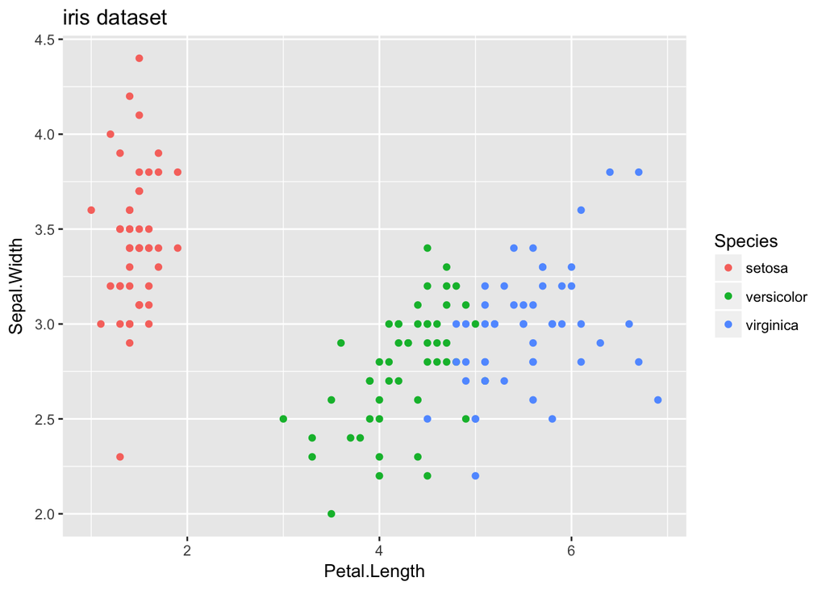

```r
ggplot(iris, aes(Petal.Length, Sepal.Width, color = Species)) +
  geom_point() +
  labs(title = "iris dataset")
```

### Model

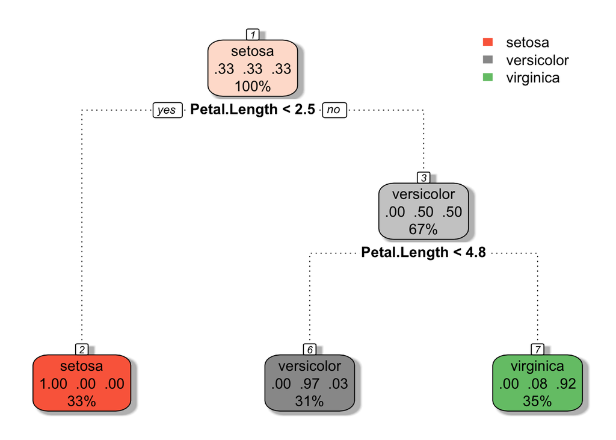

```r
fit <- train(Species ~ ., method = "rpart", data = training)
rpart.plot(fit$finalModel, extra=104,
           branch.lty=3, shadow.col="gray", nn=TRUE)
```

```r
# Evaluation on testing
y_pred <- predict(fit, newdata=testing)
y_pred_score <- predict(fit, type = "prob", newdata=testing)
table(testing$Species, y_pred)
```

```
#>             y_pred
#>              setosa versicolor virginica
#>   setosa         15          0         0
#>   versicolor      0         14         1
#>   virginica       0          2        13
```

```r
# MLmetrics::MultiLogLoss(y_pred = y_pred_score, y_true = testing$Species)  # bug in pmax
ModelMetrics::mlogLoss(testing$Species, y_pred_score)
```

```
#> [1] 0.2452304
```

## Bagging (Bootstrap aggregating)

**Method:**

1. Resample cases and recalculate predictions
2. Average or majority vote

**Notes:**

- Similar bias
- Reduce variance: averaging different predictors
- Most useful for non-linear functions

### Dataset

```r
library(ElemStatLearn)
library(data.table)
library(caret)
library(ggplot2)

data(ozone)
setDT(ozone)
ozone <- ozone[order(ozone),]
head(ozone)
```

```
#>    ozone radiation temperature wind
#> 1:     1         8          59  9.7
#> 2:     4        25          61  9.7
#> 3:     6        78          57 18.4
#> 4:     7        48          80 14.3
#> 5:     7        49          69 10.3
#> 6:     8        19          61 20.1
```

### Bagged LOESS

by hand

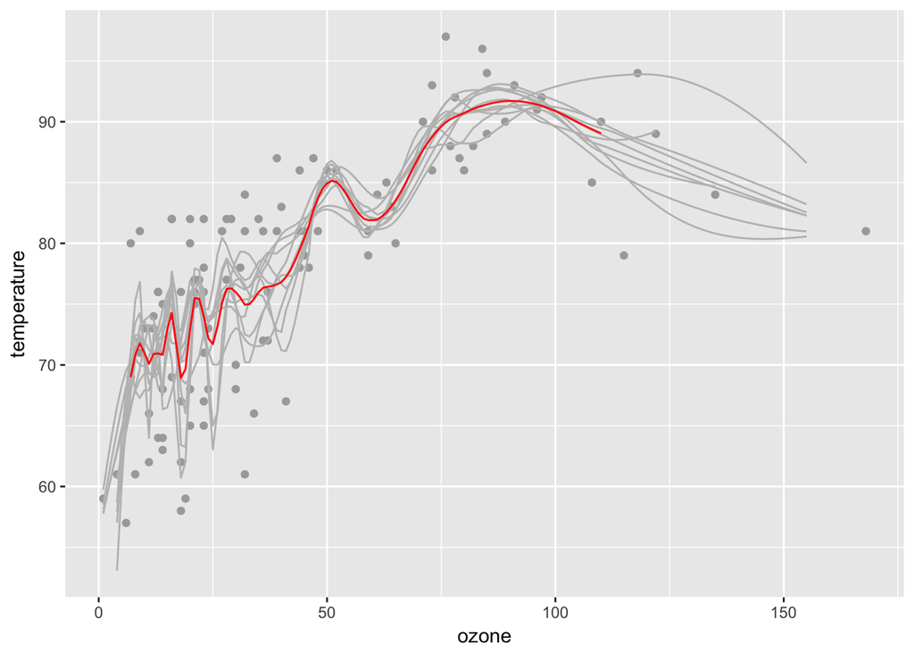

```r
sample_idx <- caret::createResample(ozone$temperature, times = 10)

loess_ozone <- function(ozone, idx) {
  d <- ozone[idx,]; d[order(ozone)]
  loess0 <- loess(temperature ~ ozone, data = d, span = 0.2)
  out <- predict(loess0, data.table(ozone=1:155))
  data.table(ozone = 1:155, temperature = out)
}

res_list <- lapply(sample_idx, loess_ozone, ozone = ozone)
ll <- rbindlist(res_list, idcol = "group")

g <- ggplot(NULL, aes(ozone, temperature)) +
  geom_point(data = ozone, colour = "darkgrey")

g + geom_line(aes(group = group), data = ll, colour = "grey") +
  geom_line(
  data = ll[, .(temperature=mean(temperature, na.rm = F)), ozone],
  colour = "red"
)
```

by `caret` package

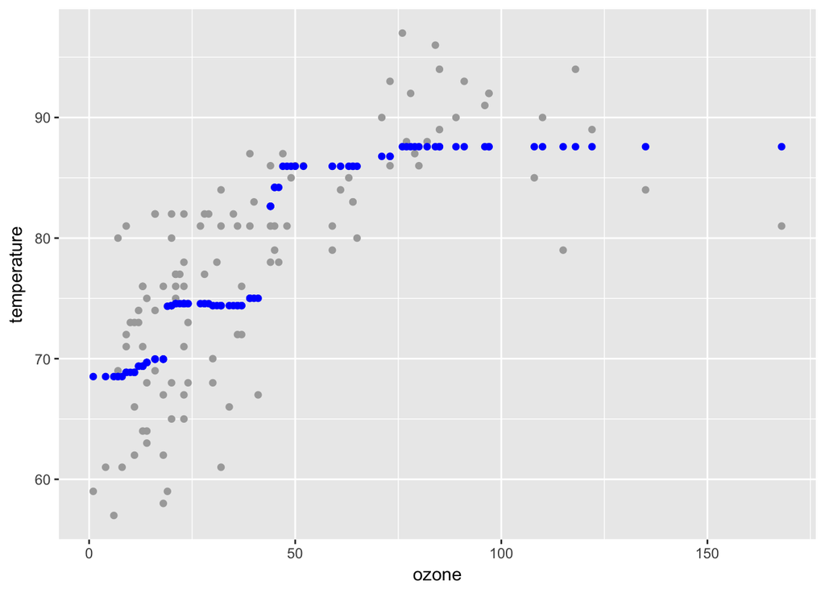

```r
library(party)

tree_bag <- caret::bag(
  x = ozone[, .(ozone)], y = ozone$temperature,
  B = 10,
  bagControl = bagControl(
    fit = ctreeBag$fit,
    predict = ctreeBag$pred,
    aggregate = ctreeBag$aggregate)
)

new_data <- data.table(
  ozone[, .(ozone)],
  temperature = predict(tree_bag, newdata = ozone[, .(ozone)])
)
g + geom_point(data = new_data, colour = "blue")
```

## Random Forest

An extension to bagging

**Method:**

1. Resample cases and recalculate predictions (Bootstapp ing)
2. At each split, bootstrp variables (subset of variable to be used)
3. Average or majority vote

**Pros:**

1. Accuracy

**Cons:**

1. Speed low
2. Interpretability low
3. Overfitting

### Data

```r
library(ggplot2)
library(caret)
library(data.table)
library(randomForest)

data(iris); setDT(iris)

train_idx = createDataPartition(iris$Species, p = 0.7, list=FALSE)
training <- iris[train_idx,]
testing <- iris[-train_idx,]
```

### Random forest

```r
fit <- train(Species ~ .,
             data = training,
             method = "rf",
             prox = TRUE) # for showing proximity
print(fit)
```

```
#> Random Forest
#>
#> 105 samples
#>   4 predictor
#>   3 classes: 'setosa', 'versicolor', 'virginica'
#>
#> No pre-processing
#> Resampling: Bootstrapped (25 reps)
#> Summary of sample sizes: 105, 105, 105, 105, 105, 105, ...
#> Resampling results across tuning parameters:
#>
#>   mtry  Accuracy   Kappa
#>   2     0.9553563  0.9321664
#>   3     0.9544039  0.9306245
#>   4     0.9498489  0.9234238
#>
#> Accuracy was used to select the optimal model using the largest value.
#> The final value used for the model was mtry = 2.
```

```r
# Getting single tree
randomForest::getTree(fit$finalModel, k=2)
```

```
#>    left daughter right daughter split var split point status prediction
#> 1              2              3         4        0.70      1          0
#> 2              0              0         0        0.00     -1          1
#> 3              4              5         4        1.70      1          0
#> 4              6              7         1        7.10      1          0
#> 5              0              0         0        0.00     -1          3
#> 6              8              9         1        6.05      1          0
#> 7              0              0         0        0.00     -1          3
#> 8              0              0         0        0.00     -1          2
#> 9             10             11         3        5.15      1          0
#> 10             0              0         0        0.00     -1          2
#> 11             0              0         0        0.00     -1          3
```

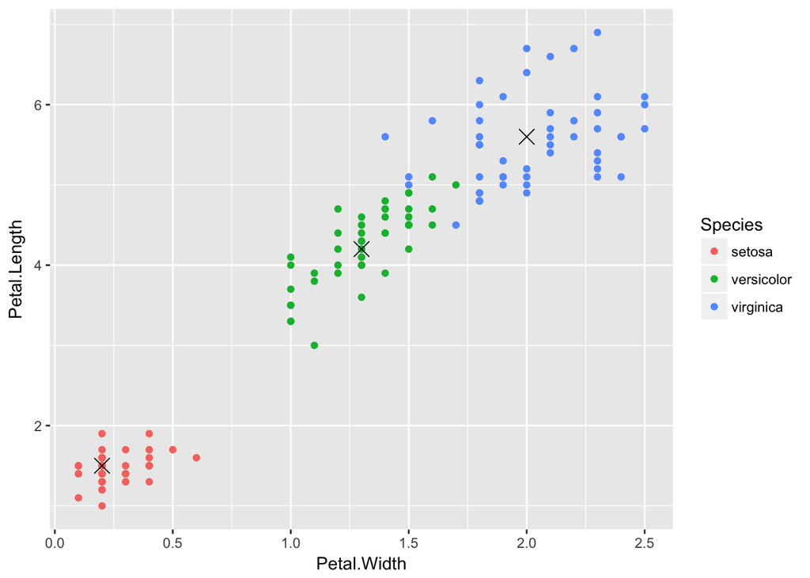

```r
# Class "centers"
centers <- classCenter(x = training[, .(Petal.Width, Petal.Length)],
            label = training[, Species],
            prox = fit$finalModel$proximity)
centers <- data.table(centers, Species = rownames(centers))
ggplot(NULL, aes(Petal.Width, Petal.Length, color = Species)) +
  geom_point(data = iris) +
  geom_point(data = centers, shape = 4, color = "black", size = 4)
```

### Cross validation

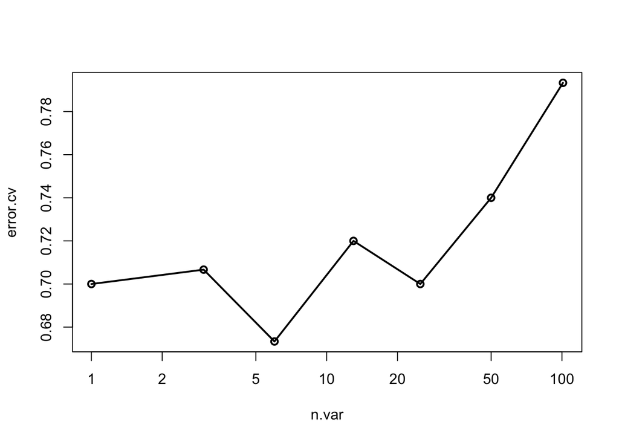

```r
set.seed(647)
myiris <- cbind(iris[1:4], matrix(runif(96 * nrow(iris)), nrow(iris), 96))
result <- rfcv(myiris, iris$Species, cv.fold=3)
with(result, plot(n.var, error.cv, log="x", type="o", lwd=2))
```

## Boosting

**Basic idea:**

1. Take a lot of (possibly) weak predictors
2. **Weight** them and add them
3. Get stronger predictor

## Model Based Prediction

Assumption to the distribution of the feature $x$ given the class $k$:

$$f_k(x) = Pr(X= x|Y = k)$$

- Linear Discriminant Analysis: assumes $f_k(x)$ is multivariate Gaussian with same covariances
- Quadratic Discriminant Analysis: assumes $f_k(x)$ is multivariate Gaussian with different covariances
- Naive Bayes: assumes independence between features

# Quiz

For this quiz we will be using several R packages. R package versions change over time, the right answers have been checked using the following versions of the packages.

- AppliedPredictiveModeling: v1.1.6
- caret: v6.0.47
- ElemStatLearn: v2012.04-0
- pgmm: v1.1
- rpart: v4.1.8

## Problem 1

```r
library(AppliedPredictiveModeling)
data(segmentationOriginal); setDT(segmentationOriginal)
library(caret)
library(data.table)
library(rpart.plot)
set.seed(125)

# 1. Subset the data to a training set and testing set based on the Case variable in the data set.
train_idx <- createDataPartition(segmentationOriginal$Case, p = 0.7, list=FALSE)

# 2. Set the seed to 125 and fit a CART model with the rpart method using all predictor variables and default caret settings.
training <- segmentationOriginal[Case == "Train"]
testing <- segmentationOriginal[Case == "Test"]

fit <- train(Class ~., data = training[, -c("Cell","Case")], method = "rpart")
predictors(fit)
```

```
#>  [1] "TotalIntenCh2"          "FiberWidthCh1"
#>  [3] "AvgIntenCh2"            "TotalIntenStatusCh2"
#>  [5] "AvgIntenStatusCh2"      "TotalIntenCh1"
#>  [7] "ShapeP2ACh1"            "ConvexHullAreaRatioCh1"
#>  [9] "EqEllipseLWRCh1"        "ShapeBFRCh1"
#> [11] "ShapeLWRCh1"
```

```r
print(fit$finalModel)
```

```
#> n= 1009
#>
#> node), split, n, loss, yval, (yprob)
#>       * denotes terminal node
#>
#> 1) root 1009 373 PS (0.63032706 0.36967294)
#>   2) TotalIntenCh2< 45323.5 454  34 PS (0.92511013 0.07488987) *
#>   3) TotalIntenCh2>=45323.5 555 216 WS (0.38918919 0.61081081)
#>     6) FiberWidthCh1< 9.673245 154  47 PS (0.69480519 0.30519481) *
#>     7) FiberWidthCh1>=9.673245 401 109 WS (0.27182045 0.72817955) *
```

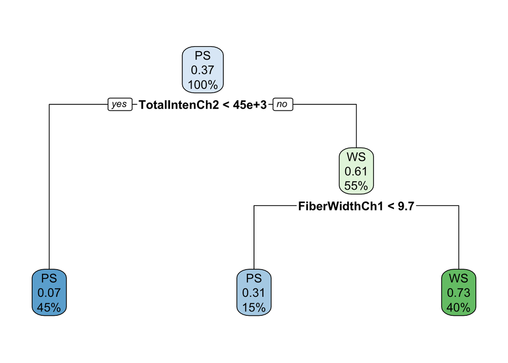

```r
rpart.plot(fit$finalModel)
```

In the final model what would be the final model prediction for cases with the following variable values:

```r
newdata <- training[0]
newdata <- rbind(newdata, data.table(
  TotalIntench2 = c(23000, 50000, 57000, NA),
  FiberWidthCh1 = c(10, 10, 8, 8),
  PerimStatusCh1= c(2, NA, NA, 2),
  VarIntenCh4 = c(NA, 100, 100, 100)
), fill = TRUE)
predict(fit$finalModel, newdata = newdata, type = "class")
```

```
#>  1  2  3  4
#> WS WS PS PS
#> Levels: PS WS
```

## Problem 3

```r
library(pgmm)
data(olive)
dim(olive)
```

```
#> [1] 572  10
```

```r
head(olive)
```

```
#>   Region Area Palmitic Palmitoleic Stearic Oleic Linoleic Linolenic
#> 1      1    1     1075          75     226  7823      672        36
#> 2      1    1     1088          73     224  7709      781        31
#> 3      1    1      911          54     246  8113      549        31
#> 4      1    1      966          57     240  7952      619        50
#> 5      1    1     1051          67     259  7771      672        50
#> 6      1    1      911          49     268  7924      678        51
#>   Arachidic Eicosenoic
#> 1        60         29
#> 2        61         29
#> 3        63         29
#> 4        78         35
#> 5        80         46
#> 6        70         44
```

```r
olive <- olive[,-1]
treeModel <- train(Area ~ ., data=olive, method="rpart2")
treeModel
```

```
#> CART
#>
#> 572 samples
#>   8 predictor
#>
#> No pre-processing
#> Resampling: Bootstrapped (25 reps)
#> Summary of sample sizes: 572, 572, 572, 572, 572, 572, ...
#> Resampling results across tuning parameters:
#>
#>   maxdepth  RMSE       Rsquared   MAE
#>   1         1.1243364  0.7773887  0.8661719
#>   2         0.7451044  0.9015117  0.5771667
#>   3         0.6553629  0.9236639  0.4406533
#>
#> RMSE was used to select the optimal model using the smallest value.
#> The final value used for the model was maxdepth = 3.
```

```r
newdata <- as.data.frame(t(colMeans(olive)))
predict(treeModel, newdata) # 2.875
```

```
#>     1
#> 2.875
```

2.875. It is strange because Area should be a qualitative variable - but tree is reporting the average value of Area as a numeric variable in the leaf predicted for newdata

## Problem 4

```r
library(ElemStatLearn)
library(data.table)
data(SAheart); setDT(SAheart)

SAheart[, chd := as.factor(chd)]

set.seed(8484)
train <- sample(1:dim(SAheart)[1], size=dim(SAheart)[1]/2, replace=F)
trainSA <- SAheart[train,]
testSA <- SAheart[-train,]

set.seed(13234)
(logitModel <- train(
  chd ~ age + alcohol + obesity + tobacco +
    typea + ldl, data=trainSA, method="glm",
  family="binomial"))
```

```
#> Generalized Linear Model
#>
#> 231 samples
#>   6 predictor
#>   2 classes: '0', '1'
#>
#> No pre-processing
#> Resampling: Bootstrapped (25 reps)
#> Summary of sample sizes: 231, 231, 231, 231, 231, 231, ...
#> Resampling results:
#>
#>   Accuracy  Kappa
#>   0.695615  0.323028
```

```r
missClass <- function(values,prediction) {
  sum(((prediction > 0.5)*1) != values)/length(values)
}

predictTrain <- predict(logitModel, trainSA)
predictTest <- predict(logitModel, testSA)

# Training Set Misclassification rate
missClass(trainSA$chd, predictTrain) # 0.2727273
```

```
#> [1] NA
```

```r
# Test Set Misclassification rate
missClass(testSA$chd, predictTest) # 0.3116883
```

```
#> [1] NA
```

## Problem 5.

```r
library(ElemStatLearn)
library(randomForest)
data(vowel.train)
data(vowel.test)
head(vowel.train)
```

```
#>   y    x.1   x.2    x.3   x.4    x.5   x.6    x.7    x.8    x.9   x.10
#> 1 1 -3.639 0.418 -0.670 1.779 -0.168 1.627 -0.388  0.529 -0.874 -0.814
#> 2 2 -3.327 0.496 -0.694 1.365 -0.265 1.933 -0.363  0.510 -0.621 -0.488
#> 3 3 -2.120 0.894 -1.576 0.147 -0.707 1.559 -0.579  0.676 -0.809 -0.049
#> 4 4 -2.287 1.809 -1.498 1.012 -1.053 1.060 -0.567  0.235 -0.091 -0.795
#> 5 5 -2.598 1.938 -0.846 1.062 -1.633 0.764  0.394 -0.150  0.277 -0.396
#> 6 6 -2.852 1.914 -0.755 0.825 -1.588 0.855  0.217 -0.246  0.238 -0.365
```

```r
head(vowel.test)
```

```
#>   y    x.1    x.2    x.3    x.4    x.5   x.6    x.7   x.8    x.9   x.10
#> 1 1 -1.149 -0.904 -1.988  0.739 -0.060 1.206  0.864 1.196 -0.300 -0.467
#> 2 2 -2.613 -0.092 -0.540  0.484  0.389 1.741  0.198 0.257 -0.375 -0.604
#> 3 3 -2.505  0.632 -0.593  0.304  0.496 0.824 -0.162 0.181 -0.363 -0.764
#> 4 4 -1.768  1.769 -1.142 -0.739 -0.086 0.120 -0.230 0.217 -0.009 -0.279
#> 5 5 -2.671  3.155 -0.514  0.133 -0.964 0.234 -0.071 1.192  0.254 -0.471
#> 6 6 -2.509  1.326  0.354  0.663 -0.724 0.418 -0.496 0.713  0.638 -0.204
```

```r
dim(vowel.train) # 528  11
```

```
#> [1] 528  11
```

```r
dim(vowel.test) # 462  11
```

```
#> [1] 462  11
```

```r
vowel.train$y <- as.factor(vowel.train$y)
vowel.test$y <- as.factor(vowel.test$y)

set.seed(33833)
modelRf <- randomForest(y ~ ., data = vowel.train, importance = FALSE)

o <- order(varImp(modelRf), decreasing=T)
rownames(varImp(modelRf))[o]
```

```
#>  [1] "x.2"  "x.1"  "x.5"  "x.6"  "x.8"  "x.4"  "x.9"  "x.3"  "x.7"  "x.10"
```

```r
# The order of the variables is:
#  x.2, x.1, x.5, x.6, x.8, x.4, x.9, x.3, x.7,x.10
```